# MR (IJ) and MR (field) on the continuous/MD path — campaign mdf1, four cells

- Show All Code
- Hide All Code
- View Source

Cross-cell summary of the committed combined bundles: Table-2 layout, bound location, joint pair, regime diagnostics, display

Author

Larry F. León

Published

September 7, 2026

Self-contained: reads only the campaign’s combined bundles beside this document (`mr_md_harm/*_mdf1_d5000/*_combined_1_2000.rds`). Every estimator column is **oriented** (positive = harm; the gate works on $-\,$`cd4_change`); `betaHhat_*` are raw and are oriented here with $-1$. Bounds are read by **location** against mean-difference thresholds (CD4 cells/mm³; 0 = no harm, 10 = the design’s consistency threshold, 20, 30 = the search’s effect threshold, 40 = the planted harm MD), never as significance at the null. Coverage carries Wilson 95% intervals; bias is given in MD units and in SD units. The survival ranges quoted for comparison are from `dev/tasks/HANDOFF_continuous_field_mac_2026-09-07.md` §3 (12.5%-prevalence cells at 2,000 replicates).

```r
suppressPackageStartupMessages({ library(forestsearch); library(ggplot2); library(knitr) })
tag <- "mdf1"
cells <- list(list(lab = "md40 n500",  md = "40",  n = 500L), list(lab = "md120 n500", md = "120", n = 500L),
              list(lab = "null n500",  md = "null", n = 500L), list(lab = "md40 n700",  md = "40",  n = 700L))
stem_of <- function(cl) if (cl$md == "null") sprintf("fs_maxeffCons_mr_field_mdnull_knoise0_n%d_%s", cl$n, tag) else sprintf("fs_maxeffCons_mr_field_md%s_knoise0_n%d_%s", cl$md, cl$n, tag)
path_of <- function(cl) { s <- stem_of(cl); f <- Sys.glob(file.path("mr_md_harm", paste0(s, "_d5000"), paste0(s, "_combined_*.rds"))); if (length(f)) f[1] else NA_character_ }
z95 <- qnorm(0.95)
wilson <- function(x, n, z = qnorm(0.975)) { if (!is.finite(x) || n <= 0) return(c(NA, NA)); ctr <- (x + z^2/(2*n))/(1 + z^2/n); hw <- z*sqrt(x*(1-x)/n + z^2/(4*n^2))/(1 + z^2/n); c(ctr - hw, ctr + hw) }
fmtw <- function(x, n) { w <- wilson(x, n); sprintf("%.3f (%.3f, %.3f)", x, w[1], w[2]) }
mfin <- function(x) { x <- x[is.finite(x)]; if (length(x)) mean(x) else NA_real_ }
sdfin <- function(x) { x <- x[is.finite(x)]; if (length(x) > 1) sd(x) else NA_real_ }
rows <- list(); bl <- list(H = list(), Hc = list()); jt <- list(); rg <- list(); disp <- list(); status <- list()
for (cl in cells) {
  p <- path_of(cl); if (is.na(p)) { status[[cl$lab]] <- "NOT RUN (deferred)"; next }
  b <- readRDS(p); r <- b$results; d <- r[r$detected %in% 1L, ]
  or <- -1; d$bH <- or * d$betaHhat_H; d$bHc <- or * d$betaHhat_Hc
  status[[cl$lab]] <- sprintf("%d reps, %d detected (%.3f), pkg %s", nrow(r), nrow(d), mean(r$detected), b$meta$pkg_version)
  struct <- list(H = or * b$truth$effect_Q, Hc = or * b$truth$effect_Qc)
  for (sfx in c("H", "Hc")) {
    side <- if (sfx == "H") "lower" else "upper"; sgn <- if (side == "lower") -1 else 1
    beta <- d[[if (sfx == "H") "bH" else "bHc"]]
    ests <- list(naive = list(e = d[[paste0("nv_", sfx, "_est")]], lo = d[[paste0("nv_", sfx, "_lo")]], hi = d[[paste0("nv_", sfx, "_hi")]], se = d[[paste0("nv_", sfx, "_se")]]),
                 oracle = list(e = d[[paste0("or_", sfx, "_est")]], lo = d[[paste0("or_", sfx, "_lo")]], hi = d[[paste0("or_", sfx, "_hi")]], se = d[[paste0("or_", sfx, "_se")]]),
                 `MR (IJ)` = list(e = d[[paste0("mr_", sfx, "_est")]], lo = d[[paste0("mr_", sfx, "_lo")]], hi = d[[paste0("mr_", sfx, "_hi")]], se = d[[paste0("mr_", sfx, "_se_ij")]]),
                 `MR (field)` = list(e = d[[paste0("fld_", sfx, "_est2")]], lo = d[[paste0("fld_", sfx, "_lo2s")]], hi = d[[paste0("fld_", sfx, "_hi2s")]], se = d[[paste0("fld_", sfx, "_se")]]))
    for (k in names(ests)) {
      ec <- ests[[k]]; e <- ec$e; se <- ec$se
      tgt <- if (k == "oracle") rep(struct[[sfx]], length(e)) else beta
      ctr <- if (k == "MR (field)") d[[paste0("mr_", sfx, "_est")]] else e
      b1 <- if (k == "MR (field)") d[[paste0("fld_", sfx, if (side == "upper") "_up1s" else "_lo1s")]] else e + sgn * z95 * se
      ok <- is.finite(e) & is.finite(tgt); ok2 <- ok & is.finite(ec$lo) & is.finite(ec$hi); ok1 <- ok & is.finite(b1)
      bias <- mean(e[ok] - tgt[ok]); sde <- sdfin(e); sem <- mfin(se)
      c2 <- mean(tgt[ok2] >= ec$lo[ok2] & tgt[ok2] <= ec$hi[ok2]); c1 <- if (side == "lower") mean(tgt[ok1] >= b1[ok1]) else mean(tgt[ok1] <= b1[ok1])
      rows[[length(rows) + 1]] <- data.frame(cell = cl$lab, block = sfx, estimator = k, n = sum(ok), bias = bias, bias_sd = bias / sde, SD = sde, SE = sem, SE_SD = sem / sde,
                                             cov2 = c2, cov2_w = fmtw(c2, sum(ok2)), cov1 = c1, cov1_w = fmtw(c1, sum(ok1)), side = side,
                                             halfwidth = mfin((ec$hi - ec$lo) / 2), margin1 = mfin(sgn * (b1 - ctr)), stringsAsFactors = FALSE)
      if (k != "oracle") {
        thr <- if (sfx == "H") c(0, 10, 20, 30, 40) else c(0, 10, 20, 30)
        bb <- b1[is.finite(b1)]
        sh <- vapply(thr, function(t) if (side == "lower") mean(bb >= t) else mean(bb <= t), numeric(1))
        bl[[sfx]][[length(bl[[sfx]]) + 1]] <- cbind(data.frame(cell = cl$lab, block = sfx, estimator = k, n = length(bb), mean = mean(bb), median = median(bb), q10 = unname(quantile(bb, .1)), q90 = unname(quantile(bb, .9)), stringsAsFactors = FALSE),
                                      as.data.frame(as.list(setNames(sh, sprintf(if (side == "lower") "P(L>=%g)" else "P(U<=%g)", thr))), check.names = FALSE))
      }
    }
  }
  # joint pair
  dj <- d[is.finite(d$fld_joint_gamma), ]
  pairs <- list(`separate 95% field bounds` = list(lo = dj$fld_H_lo1s, up = dj$fld_Hc_up1s), `Bonferroni (gamma = 0.025)` = list(lo = dj$fld_joint_bonf_loH, up = dj$fld_joint_bonf_upHc), `calibrated gamma` = list(lo = dj$fld_joint_loH, up = dj$fld_joint_upHc))
  for (nm in names(pairs)) { pp <- pairs[[nm]]; cH <- dj$bH >= pp$lo; cC <- dj$bHc <= pp$up
    jt[[length(jt) + 1]] <- data.frame(cell = cl$lab, pair = nm, n = nrow(dj), joint = fmtw(mean(cH & cC), nrow(dj)), cov_H = mean(cH), cov_Hc = mean(cC), margin_H = mean(dj$mr_H_est - pp$lo), margin_Hc = mean(pp$up - dj$mr_Hc_est), stringsAsFactors = FALSE) }
  # regime diagnostics
  rg[[length(rg) + 1]] <- data.frame(cell = cl$lab, n_det = nrow(d), mean_pH = mean(d$n_harm), p_hat_mean = mean(d$p_hat_H), p_hat_med = median(d$p_hat_H), p_hat_lt05 = mean(d$p_hat_H < 0.5), p_hat_ge09 = mean(d$p_hat_H >= 0.9),
                                     gamma_mean = mean(dj$fld_joint_gamma), corr_lam = mean(dj$fld_joint_corr), nfit_mean = mean(d$fld_Hc_nfit), share_newfit = mean(d$fld_Hc_share_newfit),
                                     sd_btc_naive = sdfin(d$mr_Hc_est) / mfin(d$nv_Hc_se), lamc_naive = mfin(d$fld_Hc_se) / mfin(d$nv_Hc_se), ij_sd_H = mfin(d$mr_H_se_ij) / sdfin(d$mr_H_est), ij_sd_Hc = mfin(d$mr_Hc_se_ij) / sdfin(d$mr_Hc_est),
                                     fit_secs = mean(r$fit_mr_secs), field_secs = mfin(d$fld_H_secs), comp_secs = mfin(d$fld_Hc_secs), stringsAsFactors = FALSE)
  # display rows (identity scale)
  ro <- r; ro$betaHhat_H <- or * r$betaHhat_H; ro$betaHhat_Hc <- or * r$betaHhat_Hc
  dh <- fs_sim_bias_coverage(ro, block = "H", estimators = c("mr", "fld"), scale = "identity"); dh$block <- "H"; dh$cell <- cl$lab
  dc <- fs_sim_bias_coverage(ro, block = "Hc", estimators = c("mr", "fld"), side = "upper", scale = "identity"); dc$block <- "Hc"; dc$cell <- cl$lab
  disp[[length(disp) + 1]] <- rbind(dh, dc)
}

T2 <- do.call(rbind, rows); BL_H <- do.call(rbind, bl$H); BL_Hc <- do.call(rbind, bl$Hc)
JT <- do.call(rbind, jt); RG <- do.call(rbind, rg); DS <- do.call(rbind, disp)
```

# 1 Cells

```r
kable(data.frame(cell = names(status), status = unlist(status)), caption = "Combined bundles read (2,000 replicates per cell where present).")
```

Combined bundles read (2,000 replicates per cell where present).

|  | cell | status |
| --- | --- | --- |
| md40 n500 | md40 n500 | 2000 reps, 1998 detected (0.999), pkg 0.3.5 |
| md120 n500 | md120 n500 | 2000 reps, 2000 detected (1.000), pkg 0.3.5 |
| null n500 | null n500 | 2000 reps, 1993 detected (0.997), pkg 0.3.5 |
| md40 n700 | md40 n700 | 2000 reps, 1999 detected (1.000), pkg 0.3.5 |

# 2 Table-2 layout, both blocks

Rows naive / oracle / MR (IJ) / MR (field). Targets: $\beta(\hat H)$ and $\beta(\hat H^{c})$ (exact, per replicate); the oracle against the structural true-region effect. One-sided coverage is on the exposed side: the harm block’s LOWER bound, the complement’s UPPER bound. Field rows use their stored `lo1s` / `up1s` (Λ* q95 / q05 inversion about $\tilde\beta$); normal-based rows use est ∓ 1.645 SE.

```r
kable(T2[, c("cell","block","estimator","n","bias","bias_sd","SD","SE","SE_SD","cov2_w","cov1_w","side","halfwidth","margin1")], digits = 3,
      col.names = c("cell","block","estimator","n","bias (MD)","bias (SD units)","SD (emp)","mean SE","SE/SD","two-sided (Wilson)","one-sided (Wilson)","bound","half-width","1-sided margin"),
      caption = "Table-2 layout: bias, SD, SE, SE/SD, two-sided and one-sided coverage with Wilson intervals, half-widths and one-sided margins (MD units).")
```

Table-2 layout: bias, SD, SE, SE/SD, two-sided and one-sided coverage with Wilson intervals, half-widths and one-sided margins (MD units).

| cell | block | estimator | n | bias (MD) | bias (SD units) | SD (emp) | mean SE | SE/SD | two-sided (Wilson) | one-sided (Wilson) | bound | half-width | 1-sided margin |
| --- | --- | --- | --- | --- | --- | --- | --- | --- | --- | --- | --- | --- | --- |
| md40 n500 | H | naive | 1998 | 74.656 | 4.134 | 18.061 | 31.086 | 1.721 | 0.232 (0.214, 0.251) | 0.101 (0.088, 0.115) | lower | 60.928 | 51.132 |
| md40 n500 | H | oracle | 1998 | -0.660 | -0.033 | 19.985 | 19.806 | 0.991 | 0.943 (0.932, 0.952) | 0.952 (0.942, 0.961) | lower | 38.820 | 32.578 |
| md40 n500 | H | MR (IJ) | 1998 | 20.711 | 0.924 | 22.424 | 38.904 | 1.735 | 0.984 (0.977, 0.989) | 0.964 (0.955, 0.972) | lower | 76.251 | 63.992 |
| md40 n500 | H | MR (field) | 1998 | 9.629 | 0.392 | 24.578 | 29.547 | 1.202 | 0.978 (0.971, 0.984) | 0.950 (0.940, 0.959) | lower | 57.554 | 62.126 |
| md40 n500 | Hc | naive | 1998 | -12.740 | -1.069 | 11.918 | 12.556 | 1.054 | 0.845 (0.829, 0.861) | 0.760 (0.741, 0.778) | upper | 24.610 | 20.653 |
| md40 n500 | Hc | oracle | 1998 | -0.262 | -0.018 | 14.343 | 14.418 | 1.005 | 0.953 (0.943, 0.962) | 0.957 (0.947, 0.965) | upper | 28.260 | 23.716 |
| md40 n500 | Hc | MR (IJ) | 1998 | -4.385 | -0.363 | 12.087 | 23.521 | 1.946 | 0.999 (0.997, 1.000) | 0.994 (0.990, 0.997) | upper | 46.099 | 38.688 |
| md40 n500 | Hc | MR (field) | 1998 | -2.680 | -0.219 | 12.224 | 12.392 | 1.014 | 0.943 (0.932, 0.952) | 0.924 (0.911, 0.935) | upper | 24.186 | 22.101 |
| md120 n500 | H | naive | 2000 | 57.606 | 2.685 | 21.451 | 30.927 | 1.442 | 0.564 (0.542, 0.585) | 0.408 (0.387, 0.430) | lower | 60.615 | 50.870 |
| md120 n500 | H | oracle | 2000 | -0.684 | -0.034 | 19.989 | 19.807 | 0.991 | 0.943 (0.932, 0.952) | 0.953 (0.942, 0.961) | lower | 38.821 | 32.579 |
| md120 n500 | H | MR (IJ) | 2000 | 9.898 | 0.360 | 27.485 | 40.828 | 1.485 | 0.990 (0.984, 0.993) | 0.970 (0.961, 0.976) | lower | 80.022 | 67.156 |
| md120 n500 | H | MR (field) | 2000 | 1.840 | 0.061 | 30.387 | 31.412 | 1.034 | 0.942 (0.930, 0.951) | 0.948 (0.937, 0.957) | lower | 61.074 | 62.113 |
| md120 n500 | Hc | naive | 2000 | -10.045 | -0.781 | 12.869 | 12.823 | 0.996 | 0.892 (0.878, 0.905) | 0.829 (0.811, 0.844) | upper | 25.132 | 21.092 |
| md120 n500 | Hc | oracle | 2000 | -0.301 | -0.021 | 14.389 | 14.418 | 1.002 | 0.953 (0.942, 0.961) | 0.956 (0.946, 0.964) | upper | 28.259 | 23.715 |
| md120 n500 | Hc | MR (IJ) | 2000 | -2.657 | -0.202 | 13.136 | 24.078 | 1.833 | 1.000 (0.998, 1.000) | 0.997 (0.993, 0.998) | upper | 47.193 | 39.606 |
| md120 n500 | Hc | MR (field) | 2000 | -1.416 | -0.106 | 13.345 | 12.739 | 0.955 | 0.946 (0.935, 0.955) | 0.934 (0.923, 0.945) | upper | 24.855 | 22.202 |
| null n500 | H | naive | 1993 | 75.217 | 4.215 | 17.845 | 31.112 | 1.744 | 0.224 (0.206, 0.243) | 0.093 (0.081, 0.106) | lower | 60.979 | 51.175 |
| null n500 | H | oracle | 0 | NaN | NA | NA | NA | NA | NaN (NA, NA) | NaN (NA, NA) | lower | NA | NA |
| null n500 | H | MR (IJ) | 1993 | 21.068 | 0.949 | 22.200 | 38.871 | 1.751 | 0.984 (0.978, 0.989) | 0.965 (0.956, 0.972) | lower | 76.186 | 63.937 |
| null n500 | H | MR (field) | 1993 | 9.897 | 0.406 | 24.368 | 29.527 | 1.212 | 0.978 (0.971, 0.984) | 0.950 (0.940, 0.959) | lower | 57.511 | 62.167 |
| null n500 | Hc | naive | 1993 | -12.777 | -1.084 | 11.782 | 12.557 | 1.066 | 0.846 (0.829, 0.861) | 0.759 (0.740, 0.777) | upper | 24.611 | 20.655 |
| null n500 | Hc | oracle | 1993 | -0.317 | -0.028 | 11.363 | 11.653 | 1.026 | 0.956 (0.946, 0.964) | 0.953 (0.943, 0.962) | upper | 22.839 | 19.167 |
| null n500 | Hc | MR (IJ) | 1993 | -4.406 | -0.368 | 11.966 | 23.514 | 1.965 | 0.999 (0.997, 1.000) | 0.996 (0.992, 0.998) | upper | 46.087 | 38.677 |
| null n500 | Hc | MR (field) | 1993 | -2.692 | -0.222 | 12.107 | 12.393 | 1.024 | 0.945 (0.934, 0.954) | 0.926 (0.913, 0.936) | upper | 24.181 | 22.105 |
| md40 n700 | H | naive | 1999 | 76.442 | 4.359 | 17.536 | 30.959 | 1.765 | 0.189 (0.172, 0.206) | 0.067 (0.056, 0.078) | lower | 60.679 | 50.924 |
| md40 n700 | H | oracle | 1999 | 0.074 | 0.004 | 17.339 | 16.771 | 0.967 | 0.943 (0.932, 0.952) | 0.941 (0.930, 0.950) | lower | 32.872 | 27.586 |
| md40 n700 | H | MR (IJ) | 1999 | 21.350 | 0.961 | 22.224 | 36.904 | 1.661 | 0.974 (0.967, 0.981) | 0.942 (0.931, 0.952) | lower | 72.330 | 60.702 |
| md40 n700 | H | MR (field) | 1999 | 10.069 | 0.410 | 24.564 | 29.205 | 1.189 | 0.970 (0.962, 0.977) | 0.947 (0.936, 0.956) | lower | 56.766 | 61.905 |
| md40 n700 | Hc | naive | 1999 | -8.590 | -0.829 | 10.359 | 10.384 | 1.002 | 0.870 (0.855, 0.884) | 0.797 (0.779, 0.814) | upper | 20.351 | 17.080 |
| md40 n700 | Hc | oracle | 1999 | 0.186 | 0.015 | 12.100 | 12.179 | 1.007 | 0.950 (0.940, 0.959) | 0.955 (0.945, 0.963) | upper | 23.871 | 20.033 |
| md40 n700 | Hc | MR (IJ) | 1999 | -2.628 | -0.252 | 10.424 | 19.812 | 1.901 | 0.999 (0.997, 1.000) | 0.996 (0.993, 0.998) | upper | 38.830 | 32.587 |
| md40 n700 | Hc | MR (field) | 1999 | -1.380 | -0.131 | 10.500 | 10.296 | 0.981 | 0.939 (0.928, 0.949) | 0.936 (0.925, 0.946) | upper | 20.092 | 18.175 |

```r
cmp <- data.frame(cell = T2$cell, block = T2$block, estimator = T2$estimator,
                  `bias (MD | SD)` = sprintf("%+.2f | %+.3f", T2$bias, T2$bias_sd), SD = sprintf("%.2f", T2$SD), SE = sprintf("%.2f", T2$SE),
                  `SE/SD` = sprintf("%.3f", T2$SE_SD), `two-sided` = T2$cov2_w, `one-sided` = paste(T2$cov1_w, T2$side), check.names = FALSE)
kable(cmp, caption = "Compact format: bias / SD / SE / SE-to-SD / two-sided / one-sided.")
```

Compact format: bias / SD / SE / SE-to-SD / two-sided / one-sided.

| cell | block | estimator | bias (MD \| SD) | SD | SE | SE/SD | two-sided | one-sided |
| --- | --- | --- | --- | --- | --- | --- | --- | --- |
| md40 n500 | H | naive | +74.66 \| +4.134 | 18.06 | 31.09 | 1.721 | 0.232 (0.214, 0.251) | 0.101 (0.088, 0.115) lower |
| md40 n500 | H | oracle | -0.66 \| -0.033 | 19.98 | 19.81 | 0.991 | 0.943 (0.932, 0.952) | 0.952 (0.942, 0.961) lower |
| md40 n500 | H | MR (IJ) | +20.71 \| +0.924 | 22.42 | 38.90 | 1.735 | 0.984 (0.977, 0.989) | 0.964 (0.955, 0.972) lower |
| md40 n500 | H | MR (field) | +9.63 \| +0.392 | 24.58 | 29.55 | 1.202 | 0.978 (0.971, 0.984) | 0.950 (0.940, 0.959) lower |
| md40 n500 | Hc | naive | -12.74 \| -1.069 | 11.92 | 12.56 | 1.054 | 0.845 (0.829, 0.861) | 0.760 (0.741, 0.778) upper |
| md40 n500 | Hc | oracle | -0.26 \| -0.018 | 14.34 | 14.42 | 1.005 | 0.953 (0.943, 0.962) | 0.957 (0.947, 0.965) upper |
| md40 n500 | Hc | MR (IJ) | -4.38 \| -0.363 | 12.09 | 23.52 | 1.946 | 0.999 (0.997, 1.000) | 0.994 (0.990, 0.997) upper |
| md40 n500 | Hc | MR (field) | -2.68 \| -0.219 | 12.22 | 12.39 | 1.014 | 0.943 (0.932, 0.952) | 0.924 (0.911, 0.935) upper |
| md120 n500 | H | naive | +57.61 \| +2.685 | 21.45 | 30.93 | 1.442 | 0.564 (0.542, 0.585) | 0.408 (0.387, 0.430) lower |
| md120 n500 | H | oracle | -0.68 \| -0.034 | 19.99 | 19.81 | 0.991 | 0.943 (0.932, 0.952) | 0.953 (0.942, 0.961) lower |
| md120 n500 | H | MR (IJ) | +9.90 \| +0.360 | 27.49 | 40.83 | 1.485 | 0.990 (0.984, 0.993) | 0.970 (0.961, 0.976) lower |
| md120 n500 | H | MR (field) | +1.84 \| +0.061 | 30.39 | 31.41 | 1.034 | 0.942 (0.930, 0.951) | 0.948 (0.937, 0.957) lower |
| md120 n500 | Hc | naive | -10.04 \| -0.781 | 12.87 | 12.82 | 0.996 | 0.892 (0.878, 0.905) | 0.829 (0.811, 0.844) upper |
| md120 n500 | Hc | oracle | -0.30 \| -0.021 | 14.39 | 14.42 | 1.002 | 0.953 (0.942, 0.961) | 0.956 (0.946, 0.964) upper |
| md120 n500 | Hc | MR (IJ) | -2.66 \| -0.202 | 13.14 | 24.08 | 1.833 | 1.000 (0.998, 1.000) | 0.997 (0.993, 0.998) upper |
| md120 n500 | Hc | MR (field) | -1.42 \| -0.106 | 13.35 | 12.74 | 0.955 | 0.946 (0.935, 0.955) | 0.934 (0.923, 0.945) upper |
| null n500 | H | naive | +75.22 \| +4.215 | 17.84 | 31.11 | 1.744 | 0.224 (0.206, 0.243) | 0.093 (0.081, 0.106) lower |
| null n500 | H | oracle | NaN \| NA | NA | NA | NA | NaN (NA, NA) | NaN (NA, NA) lower |
| null n500 | H | MR (IJ) | +21.07 \| +0.949 | 22.20 | 38.87 | 1.751 | 0.984 (0.978, 0.989) | 0.965 (0.956, 0.972) lower |
| null n500 | H | MR (field) | +9.90 \| +0.406 | 24.37 | 29.53 | 1.212 | 0.978 (0.971, 0.984) | 0.950 (0.940, 0.959) lower |
| null n500 | Hc | naive | -12.78 \| -1.084 | 11.78 | 12.56 | 1.066 | 0.846 (0.829, 0.861) | 0.759 (0.740, 0.777) upper |
| null n500 | Hc | oracle | -0.32 \| -0.028 | 11.36 | 11.65 | 1.026 | 0.956 (0.946, 0.964) | 0.953 (0.943, 0.962) upper |
| null n500 | Hc | MR (IJ) | -4.41 \| -0.368 | 11.97 | 23.51 | 1.965 | 0.999 (0.997, 1.000) | 0.996 (0.992, 0.998) upper |
| null n500 | Hc | MR (field) | -2.69 \| -0.222 | 12.11 | 12.39 | 1.024 | 0.945 (0.934, 0.954) | 0.926 (0.913, 0.936) upper |
| md40 n700 | H | naive | +76.44 \| +4.359 | 17.54 | 30.96 | 1.765 | 0.189 (0.172, 0.206) | 0.067 (0.056, 0.078) lower |
| md40 n700 | H | oracle | +0.07 \| +0.004 | 17.34 | 16.77 | 0.967 | 0.943 (0.932, 0.952) | 0.941 (0.930, 0.950) lower |
| md40 n700 | H | MR (IJ) | +21.35 \| +0.961 | 22.22 | 36.90 | 1.661 | 0.974 (0.967, 0.981) | 0.942 (0.931, 0.952) lower |
| md40 n700 | H | MR (field) | +10.07 \| +0.410 | 24.56 | 29.21 | 1.189 | 0.970 (0.962, 0.977) | 0.947 (0.936, 0.956) lower |
| md40 n700 | Hc | naive | -8.59 \| -0.829 | 10.36 | 10.38 | 1.002 | 0.870 (0.855, 0.884) | 0.797 (0.779, 0.814) upper |
| md40 n700 | Hc | oracle | +0.19 \| +0.015 | 12.10 | 12.18 | 1.007 | 0.950 (0.940, 0.959) | 0.955 (0.945, 0.963) upper |
| md40 n700 | Hc | MR (IJ) | -2.63 \| -0.252 | 10.42 | 19.81 | 1.901 | 0.999 (0.997, 1.000) | 0.996 (0.993, 0.998) upper |
| md40 n700 | Hc | MR (field) | -1.38 \| -0.131 | 10.50 | 10.30 | 0.981 | 0.939 (0.928, 0.949) | 0.936 (0.925, 0.946) upper |

# 3 Bound location against MD thresholds

```r
kable(BL_H, digits = 3, caption = "Harm block: one-sided 95% LOWER bound (oriented MD): location summary and share of replicates at or above each threshold ('harm at least tau' supported).")
```

Harm block: one-sided 95% LOWER bound (oriented MD): location summary and share of replicates at or above each threshold (‘harm at least tau’ supported).

| cell | block | estimator | n | mean | median | q10 | q90 | P(L>=0) | P(L>=10) | P(L>=20) | P(L>=30) | P(L>=40) |
| --- | --- | --- | --- | --- | --- | --- | --- | --- | --- | --- | --- | --- |
| md40 n500 | H | naive | 1998 | 55.193 | 54.555 | 31.810 | 78.850 | 1.000 | 0.999 | 0.981 | 0.918 | 0.797 |
| md40 n500 | H | MR (IJ) | 1998 | -11.612 | -13.145 | -39.874 | 18.203 | 0.282 | 0.170 | 0.088 | 0.042 | 0.020 |
| md40 n500 | H | MR (field) | 1998 | -9.746 | -11.398 | -37.017 | 20.761 | 0.307 | 0.185 | 0.107 | 0.054 | 0.025 |
| md120 n500 | H | naive | 2000 | 102.738 | 101.856 | 75.021 | 131.026 | 1.000 | 1.000 | 1.000 | 1.000 | 1.000 |
| md120 n500 | H | MR (IJ) | 2000 | 38.743 | 37.405 | 5.624 | 73.244 | 0.942 | 0.864 | 0.753 | 0.603 | 0.468 |
| md120 n500 | H | MR (field) | 2000 | 43.787 | 41.676 | 9.360 | 81.077 | 0.956 | 0.896 | 0.799 | 0.661 | 0.524 |
| null n500 | H | naive | 1993 | 50.298 | 49.769 | 27.281 | 73.881 | 1.000 | 0.999 | 0.960 | 0.867 | 0.709 |
| null n500 | H | MR (IJ) | 1993 | -16.614 | -18.294 | -44.618 | 12.997 | 0.211 | 0.120 | 0.065 | 0.030 | 0.015 |
| null n500 | H | MR (field) | 1993 | -14.844 | -16.708 | -42.663 | 15.641 | 0.240 | 0.138 | 0.076 | 0.037 | 0.017 |
| md40 n700 | H | naive | 1999 | 57.191 | 56.353 | 35.339 | 79.101 | 1.000 | 0.999 | 0.986 | 0.946 | 0.848 |
| md40 n700 | H | MR (IJ) | 1999 | -7.679 | -9.481 | -34.745 | 20.732 | 0.337 | 0.194 | 0.103 | 0.056 | 0.035 |
| md40 n700 | H | MR (field) | 1999 | -8.882 | -10.810 | -35.174 | 19.716 | 0.309 | 0.185 | 0.097 | 0.059 | 0.035 |

```r
kable(BL_Hc, digits = 3, caption = "Complement block: one-sided 95% UPPER bound (oriented MD): location summary and share at or below each threshold ('harm at most tau' supported).")
```

Complement block: one-sided 95% UPPER bound (oriented MD): location summary and share at or below each threshold (‘harm at most tau’ supported).

| cell | block | estimator | n | mean | median | q10 | q90 | P(U<=0) | P(U<=10) | P(U<=20) | P(U<=30) |
| --- | --- | --- | --- | --- | --- | --- | --- | --- | --- | --- | --- |
| md40 n500 | Hc | naive | 1998 | 38.796 | 38.894 | 23.288 | 53.976 | 0.001 | 0.011 | 0.058 | 0.216 |
| md40 n500 | Hc | MR (IJ) | 1998 | 65.185 | 65.389 | 49.673 | 80.818 | 0.000 | 0.000 | 0.000 | 0.004 |
| md40 n500 | Hc | MR (field) | 1998 | 48.598 | 48.832 | 32.887 | 64.423 | 0.000 | 0.002 | 0.015 | 0.068 |
| md120 n500 | Hc | naive | 2000 | 62.625 | 62.896 | 46.388 | 79.074 | 0.000 | 0.000 | 0.001 | 0.007 |
| md120 n500 | Hc | MR (IJ) | 2000 | 88.527 | 88.840 | 71.690 | 105.217 | 0.000 | 0.000 | 0.000 | 0.000 |
| md120 n500 | Hc | MR (field) | 2000 | 71.123 | 71.514 | 54.277 | 88.340 | 0.000 | 0.000 | 0.001 | 0.002 |
| null n500 | Hc | naive | 1993 | 34.133 | 34.081 | 19.056 | 49.490 | 0.003 | 0.022 | 0.114 | 0.353 |
| null n500 | Hc | MR (IJ) | 1993 | 60.526 | 60.590 | 44.881 | 76.266 | 0.000 | 0.000 | 0.001 | 0.009 |
| null n500 | Hc | MR (field) | 1993 | 43.955 | 44.153 | 28.250 | 59.483 | 0.000 | 0.006 | 0.029 | 0.120 |
| md40 n700 | Hc | naive | 1999 | 39.398 | 39.138 | 26.301 | 52.775 | 0.000 | 0.003 | 0.030 | 0.182 |
| md40 n700 | Hc | MR (IJ) | 1999 | 60.868 | 60.534 | 48.170 | 74.475 | 0.000 | 0.000 | 0.000 | 0.003 |
| md40 n700 | Hc | MR (field) | 1999 | 46.456 | 46.228 | 33.073 | 60.076 | 0.000 | 0.001 | 0.006 | 0.054 |

# 4 Joint pair

```r
kable(JT, digits = 3, caption = "Joint (Hhat lower, Hhat^c upper) coverage of (beta(Hhat), beta(Hhat^c)) with Wilson intervals: separate 95% field bounds, the Bonferroni pair, the calibrated pair; margins in MD units from the two-term de-biased estimates.")
```

Joint (Hhat lower, Hhat^c upper) coverage of (beta(Hhat), beta(Hhat^c)) with Wilson intervals: separate 95% field bounds, the Bonferroni pair, the calibrated pair; margins in MD units from the two-term de-biased estimates.

| cell | pair | n | joint | cov_H | cov_Hc | margin_H | margin_Hc |
| --- | --- | --- | --- | --- | --- | --- | --- |
| md40 n500 | separate 95% field bounds | 1998 | 0.879 (0.864, 0.892) | 0.950 | 0.924 | 62.126 | 22.101 |
| md40 n500 | Bonferroni (gamma = 0.025) | 1998 | 0.940 (0.929, 0.950) | 0.981 | 0.958 | 73.422 | 26.002 |
| md40 n500 | calibrated gamma | 1998 | 0.940 (0.929, 0.950) | 0.981 | 0.957 | 73.339 | 25.975 |
| md120 n500 | separate 95% field bounds | 2000 | 0.886 (0.872, 0.900) | 0.948 | 0.934 | 62.113 | 22.202 |
| md120 n500 | Bonferroni (gamma = 0.025) | 2000 | 0.943 (0.932, 0.952) | 0.977 | 0.965 | 73.654 | 26.202 |
| md120 n500 | calibrated gamma | 2000 | 0.943 (0.931, 0.952) | 0.977 | 0.965 | 73.550 | 26.162 |
| null n500 | separate 95% field bounds | 1993 | 0.880 (0.865, 0.894) | 0.950 | 0.926 | 62.167 | 22.105 |
| null n500 | Bonferroni (gamma = 0.025) | 1993 | 0.940 (0.928, 0.949) | 0.979 | 0.959 | 73.457 | 26.015 |
| null n500 | calibrated gamma | 1993 | 0.939 (0.928, 0.949) | 0.979 | 0.959 | 73.374 | 25.985 |
| md40 n700 | separate 95% field bounds | 1999 | 0.884 (0.870, 0.898) | 0.947 | 0.936 | 61.905 | 18.175 |
| md40 n700 | Bonferroni (gamma = 0.025) | 1999 | 0.936 (0.924, 0.946) | 0.972 | 0.963 | 73.071 | 21.425 |
| md40 n700 | calibrated gamma | 1999 | 0.935 (0.924, 0.945) | 0.971 | 0.963 | 72.984 | 21.399 |

# 5 Regime diagnostics

```r
kable(RG, digits = 3, caption = "Per cell: detected replicates, mean |Hhat|, p-hat(Hhat) (mean, median, share < 0.5 = tie regime, share >= 0.9 = settled), mean joint gamma, corr(Lambda*, Lambda*c), complement fits per replicate and share needing a new fit, SD(beta-tilde^c)/naive SE, lambda-SD^c/naive SE, IJ SE/SD on both blocks, per-replicate seconds (fit+MR+field, field, complement).")
```

Per cell: detected replicates, mean |Hhat|, p-hat(Hhat) (mean, median, share < 0.5 = tie regime, share >= 0.9 = settled), mean joint gamma, corr(Lambda*, Lambda*c), complement fits per replicate and share needing a new fit, SD(beta-tilde^c)/naive SE, lambda-SD^c/naive SE, IJ SE/SD on both blocks, per-replicate seconds (fit+MR+field, field, complement).

| cell | n_det | mean_pH | p_hat_mean | p_hat_med | p_hat_lt05 | p_hat_ge09 | gamma_mean | corr_lam | nfit_mean | share_newfit | sd_btc_naive | lamc_naive | ij_sd_H | ij_sd_Hc | fit_secs | field_secs | comp_secs |
| --- | --- | --- | --- | --- | --- | --- | --- | --- | --- | --- | --- | --- | --- | --- | --- | --- | --- |
| md40 n500 | 1998 | 72.078 | 0.155 | 0.134 | 0.990 | 0 | 0.025 | 0.091 | 581.506 | 0.057 | 0.963 | 0.987 | 1.735 | 1.946 | 14.953 | 10.982 | 0.399 |
| md120 n500 | 2000 | 74.842 | 0.189 | 0.166 | 0.974 | 0 | 0.025 | 0.045 | 522.752 | 0.062 | 1.024 | 0.993 | 1.485 | 1.833 | 17.151 | 12.502 | 0.379 |
| null n500 | 1993 | 72.077 | 0.155 | 0.133 | 0.987 | 0 | 0.025 | 0.091 | 581.906 | 0.057 | 0.953 | 0.987 | 1.751 | 1.965 | 14.744 | 10.876 | 0.410 |
| md40 n700 | 1999 | 73.257 | 0.163 | 0.146 | 0.986 | 0 | 0.025 | 0.084 | 545.793 | 0.054 | 1.004 | 0.992 | 1.661 | 1.901 | 17.648 | 12.816 | 0.420 |

# 6 The display (identity scale)

```r
kable(DS[, c("cell","block","estimator","n","bias_log","sd_emp","se_mean","b","r","cov1","cov1_ref","cov2","cov2_ref")], digits = 3,
      col.names = c("cell","block","estimator","n","bias (MD)","SD","mean SE","b","r","1-sided cov","1-sided ref","2-sided cov","2-sided ref"),
      caption = "fs_sim_bias_coverage(scale = 'identity'): b = retained bias / SD, r = mean SE / SD; refs = Gaussian bookkeeping Phi(1.645 r -/+ b) and Phi(1.96 r - b) - Phi(-1.96 r - b) at each point's own (b, r). Harm block: lower bound; complement: upper bound.")
```

fs_sim_bias_coverage(scale = ‘identity’): b = retained bias / SD, r = mean SE / SD; refs = Gaussian bookkeeping Phi(1.645 r -/+ b) and Phi(1.96 r - b) - Phi(-1.96 r - b) at each point’s own (b, r). Harm block: lower bound; complement: upper bound.

| cell | block | estimator | n | bias (MD) | SD | mean SE | b | r | 1-sided cov | 1-sided ref | 2-sided cov | 2-sided ref |
| --- | --- | --- | --- | --- | --- | --- | --- | --- | --- | --- | --- | --- |
| md40 n500 | H | mr | 1998 | 20.711 | 22.424 | 38.904 | 0.924 | 1.735 | 0.964 | 0.973 | 0.984 | 0.993 |
| md40 n500 | H | fld | 1998 | 9.629 | 24.578 | 29.547 | 0.392 | 1.202 | 0.950 | 0.944 | 0.978 | 0.972 |
| md40 n500 | Hc | mr | 1998 | -4.385 | 12.087 | 23.521 | -0.363 | 1.946 | 0.994 | 0.998 | 0.999 | 1.000 |
| md40 n500 | Hc | fld | 1998 | -2.680 | 12.224 | 12.392 | -0.219 | 1.014 | 0.924 | 0.926 | 0.943 | 0.948 |
| md120 n500 | H | mr | 2000 | 9.898 | 27.485 | 40.828 | 0.360 | 1.485 | 0.970 | 0.981 | 0.990 | 0.994 |
| md120 n500 | H | fld | 2000 | 1.840 | 30.387 | 31.412 | 0.061 | 1.034 | 0.948 | 0.949 | 0.942 | 0.957 |
| md120 n500 | Hc | mr | 2000 | -2.657 | 13.136 | 24.078 | -0.202 | 1.833 | 0.997 | 0.998 | 1.000 | 1.000 |
| md120 n500 | Hc | fld | 2000 | -1.416 | 13.345 | 12.739 | -0.106 | 0.955 | 0.934 | 0.928 | 0.946 | 0.937 |
| null n500 | H | mr | 1993 | 21.068 | 22.200 | 38.871 | 0.949 | 1.751 | 0.965 | 0.973 | 0.984 | 0.993 |
| null n500 | H | fld | 1993 | 9.897 | 24.368 | 29.527 | 0.406 | 1.212 | 0.950 | 0.944 | 0.978 | 0.973 |
| null n500 | Hc | mr | 1993 | -4.406 | 11.966 | 23.514 | -0.368 | 1.965 | 0.996 | 0.998 | 0.999 | 1.000 |
| null n500 | Hc | fld | 1993 | -2.692 | 12.107 | 12.393 | -0.222 | 1.024 | 0.926 | 0.928 | 0.945 | 0.950 |
| md40 n700 | H | mr | 1999 | 21.350 | 22.224 | 36.904 | 0.961 | 1.661 | 0.942 | 0.962 | 0.974 | 0.989 |
| md40 n700 | H | fld | 1999 | 10.069 | 24.564 | 29.205 | 0.410 | 1.189 | 0.947 | 0.939 | 0.970 | 0.970 |
| md40 n700 | Hc | mr | 1999 | -2.628 | 10.424 | 19.812 | -0.252 | 1.901 | 0.996 | 0.998 | 0.999 | 1.000 |
| md40 n700 | Hc | fld | 1999 | -1.380 | 10.500 | 10.296 | -0.131 | 0.981 | 0.936 | 0.931 | 0.939 | 0.943 |

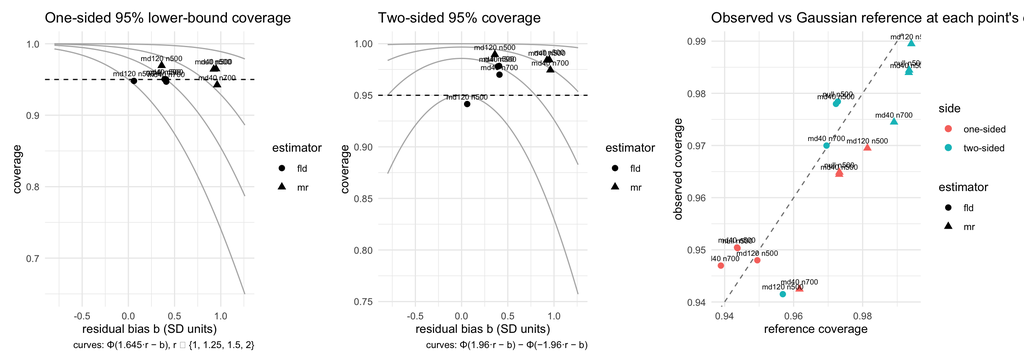

```r
DS$cell <- factor(DS$cell)
fs_plot_bias_coverage(DS[DS$block == "H", ], side = "lower")
```

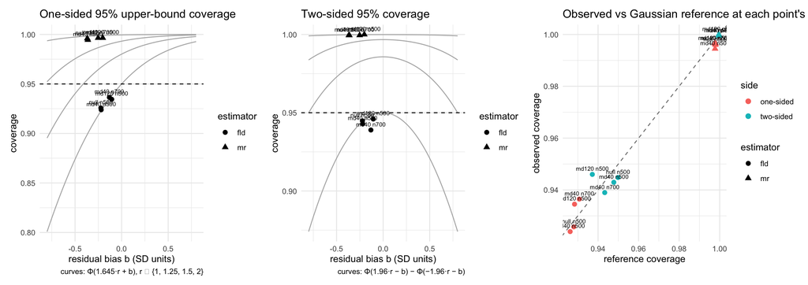

```r
fs_plot_bias_coverage(DS[DS$block == "Hc", ], side = "upper")
```

# 7 Survival ranges for comparison (handoff §3)

```r
kable(data.frame(
  `block / product` = c("Hhat field one-sided lower coverage", "Hhat IJ two-sided coverage / SE-SD", "Hhat field two-sided",
                        "Hhat^c field one-sided upper coverage / lambda-SDc-to-naive", "Hhat^c IJ two-term SE/SD", "Joint Bonferroni",
                        "Retained bias, Hhat: naive -> IJ -> field (SD units)", "Complement display points"),
  `12.5% prevalence cells (s7, map1, s7c)` = c("0.920-0.981 (tie regime at n = 1,000: 0.920)", "0.90-0.99 / 1.08-1.96", "0.85-0.92 in harm cells",
                        "0.930-0.937 at n = 500; 0.953-0.956 at n >= 1,000 / 0.97-0.99", "1.80-1.85", "0.940-0.960", "+2-6 -> +0.1-1.6 -> -0.4-0.9", "all on the Gaussian reference"),
  `31% prevalence, effMaxSG (p30sg)` = c("0.946-0.971", "0.977-0.991 / 1.34-1.67", "0.932-0.985", "0.911-0.932 (SD(beta-tilde^c)/naive 1.08-1.12)", "1.65-1.85", "0.938-0.942", "+2.1-3.7 -> +0.1-0.7 -> -0.1-0.3", "-"),
  check.names = FALSE), caption = "Survival results (all cells 2,000 replicates) quoted from the handoff, for reading beside the continuous results above.")
```

Survival results (all cells 2,000 replicates) quoted from the handoff, for reading beside the continuous results above.

| block / product | 12.5% prevalence cells (s7, map1, s7c) | 31% prevalence, effMaxSG (p30sg) |
| --- | --- | --- |
| Hhat field one-sided lower coverage | 0.920-0.981 (tie regime at n = 1,000: 0.920) | 0.946-0.971 |
| Hhat IJ two-sided coverage / SE-SD | 0.90-0.99 / 1.08-1.96 | 0.977-0.991 / 1.34-1.67 |
| Hhat field two-sided | 0.85-0.92 in harm cells | 0.932-0.985 |
| Hhat^c field one-sided upper coverage / lambda-SDc-to-naive | 0.930-0.937 at n = 500; 0.953-0.956 at n >= 1,000 / 0.97-0.99 | 0.911-0.932 (SD(beta-tilde^c)/naive 1.08-1.12) |
| Hhat^c IJ two-term SE/SD | 1.80-1.85 | 1.65-1.85 |
| Joint Bonferroni | 0.940-0.960 | 0.938-0.942 |
| Retained bias, Hhat: naive -> IJ -> field (SD units) | +2-6 -> +0.1-1.6 -> -0.4-0.9 | +2.1-3.7 -> +0.1-0.7 -> -0.1-0.3 |
| Complement display points | all on the Gaussian reference | - |